# Mall Customers Clustering

Χρήστος Γιαμακίδης Κιοσσές

2025-07-03

## Εισαγωγή

### Περιγραφή του Dataset

Το [**Mall Customers Segmentation**](https://www.kaggle.com/datasets/abdallahwagih/mall-customers-segmentation?resource=download) κοινοποιήθηκε στο *Kaggle*, ένα αποθετήριο βάσεων, συνόλων δεδομένων και θεωριών πεδίων. Εντάσσεται στον χώρο της μηχανικής μάθησης και χρησιμοποιείται για σκοπούς ταξινόμησης και επίδειξης αλγορίθμων συσταδοποίησης. Παρέχει δεδομένα για 200 άτομα που επισκέπτονται ένα εμπορικό κέντρο και πιο συγκεκριμένα δημογραφικές τους πληροφορίες, ετήσιο εισόδημα και καταναλωτικές τους συνήθειες.

### Επιχειρηματική Αναλυτική

Η ανάλυση των δεδομένων του dataset επιτρέπει στη διοίκηση του εμπορικού κέντρου και των εσωτερικών του καταστημάτων, να κατανοήσει καλύτερα το προφίλ των πελατών τους και να πάρει στοχευμένες αποφάσεις. Μέσω της συσταδοποίησης, μπορούμε να εντοπίσουμε ομάδες πελατών με παρόμοια συμπεριφορά, γεγονός που συμβάλλει στη **στοχευμένη εμπορική στρατηγική**, τη **βελτιστοποίηση αποθεμάτων**, τη **διαμόρφωση προγραμμάτων** εκπτώσεων και την **ενίσχυση** της σχέσης με τους πιο κερδοφόρους πελάτες.

## Πιθανά Επιχειρηματικά Ερωτήματα

- Υπάρχουν σαφή clusters πελατών;
- Ποιες δημογραφικές ομάδες έχουν υψηλότερο spending score;
- Υπάρχει σχέση μεταξύ εισοδήματος και δαπάνης;
- Ποιες στρατηγικές μπορούν να αυξήσουν τις δαπάνες κάποιων ομάδων;

## Περιγραφή των Μεταβλητών

Το dataset αποτελείται από 200 εγγραφές και 5 μεταβλητές.

Αναλυτικός πίνακας με τα χαρακτηριστικά των πελατών:

Μεταβλητή

Περιγραφή

Τύπος

Εύρος

Μονάδα Μέτρησης

CustomerID

Μοναδικό αναγνωριστικό πελάτη

Αριθμητική

1 - 200

Genre

Φύλο

Κατηγορική

Female, Male

Age

Ηλικία

Αριθμητική

18 - 70

Annual Income

Ετήσια εισόδημα

Αριθμητική

15 - 137

Χιλιάδες Δολλάρια ($)

Spending Score

Ατομική βαθμολογία που αποδίδεται από το εμπορικό κέντρο, με βάση την καταναλωτική συμπεριφορά και τις δαπάνες

Αριθμητική

1 - 99

## Έλεγχος εγκυρότητας του dataset

Παρατηρούμε πως το dataset δεν έχει **missing values**, αλλά ούτε και **διπλότυπες εγγραφές**.

**Ελλιπείς Τιμές**

```r
cat(sum(is.na(customers)))
```

```
## 0
```

**Διπλότυπες Εγγραφές**

```r
cat(sum(duplicated(customers)))
```

```
## 0
```

## Περιγραφικά Στατιστικά

### Μέτρα Κεντρικής Τάσης

Αφαιρούμε την κατηγορική μεταβλητή *Genre* και το μοναδικό αναγνωριστικό του κάθε πελάτη *CustomerID*.

```r
customers_numeric <- subset(customers, select = -c(CustomerID, Genre))
```

Συνοπτικά στατιστικά για τις αριθμητικές μεταβλητές:

| Metrics | Age | Annual Income | Spending Score |
| --- | --- | --- | --- |
| 1st Qu. | 28.75 | 41.50 | 34.75 |
| Median | 36.00 | 61.50 | 50.00 |
| Mean | 38.85 | 60.56 | 50.20 |
| 3rd Qu. | 49.00 | 78.00 | 73.00 |

### Μέτρα Διασποράς

Συνοπτικά στατιστικά για τις αριθμητικές μεταβλητές:

| Metrics | Age | Annual Income | Spending Score |
| --- | --- | --- | --- |
| Standard Deviation | 13.96901 | 26.26472 | 25.82352 |
| Sample Variance | 195.13317 | 689.83558 | 666.85427 |

## Διαγράμματα Συσχετίσεων

### *Γράφημα 1:* **Ιστόγραμμα Κατανομής Ηλικίας Πελατών**

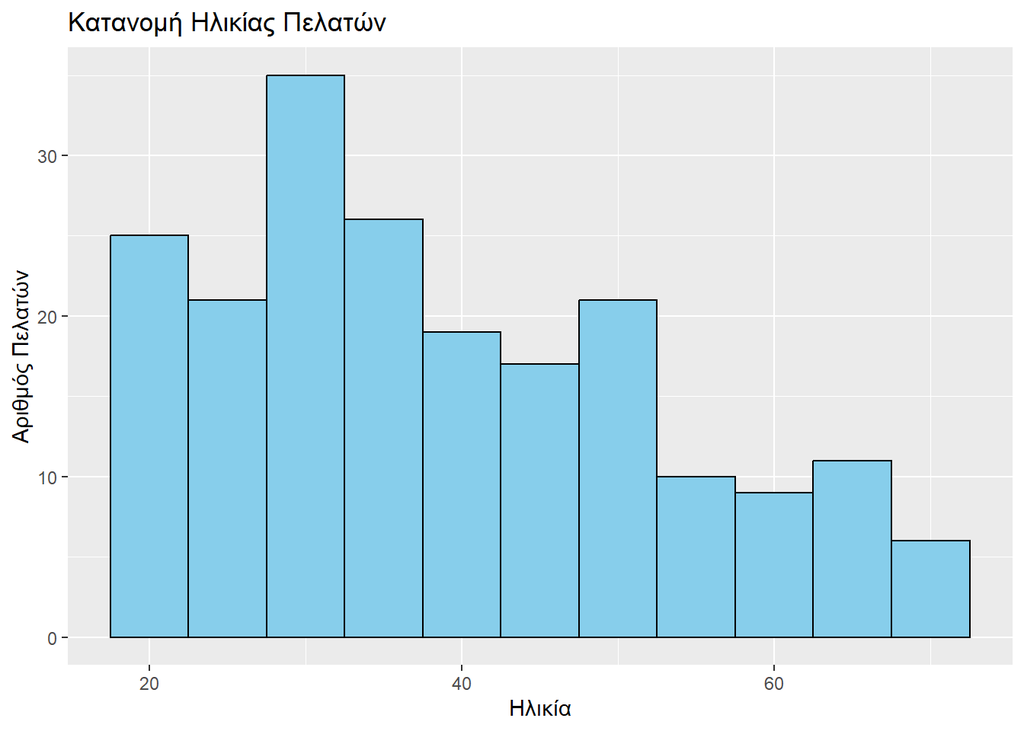

```r
ggplot(customers, aes(Age)) +
  geom_histogram(binwidth = 5, fill = "skyblue", color = "black") +
  labs(title = "Κατανομή Ηλικίας Πελατών",
       x = "Ηλικία",
       y = "Αριθμός Πελατών")
```

**Σχόλιο**  
Το παραπάνω διάγραμμα δείχνει πώς κατανέμονται οι ηλικίες των πελατών στο dataset. Παρατηρούμε πως τα περισσότερα datapoints βρίσκονται ηλικιακά μεταξύ των 20 και 40 ετών. Η πληροφορία αυτή είναι χρήσιμη για την αναγνώριση του βασικού ηλικιακού target group.

### *Γράφημα 2:* **Boxplot Ετήσιου εισοδήματος ανά φύλο**

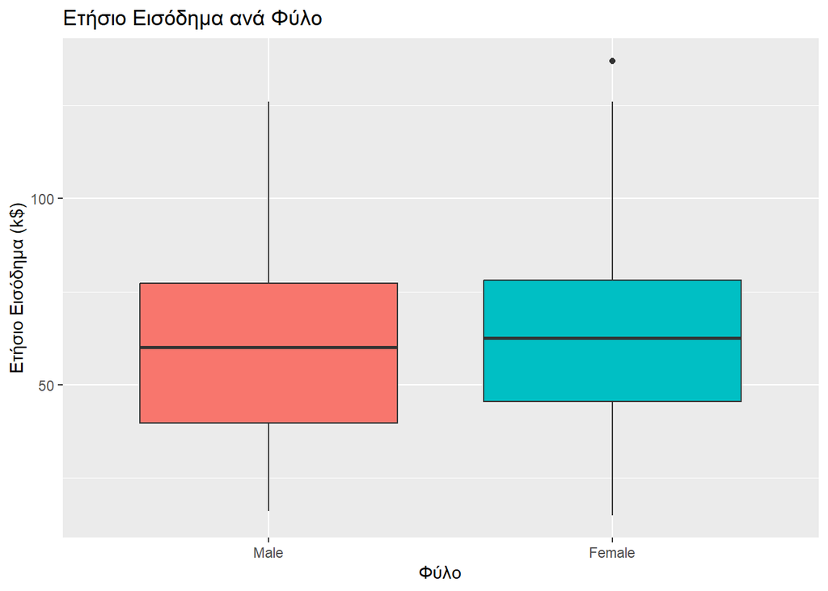

```r
ggplot(customers, aes(x = Genre, y = AnnualIncome, fill = Genre)) +
  geom_boxplot() +
  labs(title = "Ετήσιο Εισόδημα ανά Φύλο",
       x = "Φύλο",
       y = "Ετήσιο Εισόδημα (k$)") +
  theme(legend.position = "none")
```

**Σχόλιο**  
Παρατηρούμε πως οι γυναίκες του dataset έχουν ελαφρώς μεγαλύτερο μέσο ετήσιο εισόδημα από τους άνδρες, κάτι που ωστόσο μπορεί να επηρεάζεται από την ύπαρξη outlier (μαύρη κουκίδα πάνω από το box). Αυτή η πληροφορία είναι χρήσιμη για την στοχευμένη δημιουργία προσφορών προσφορών.

### *Γράφημα 3:* **Scatter Plot Ετήσιου Εισοδήματος vs Spending Score**

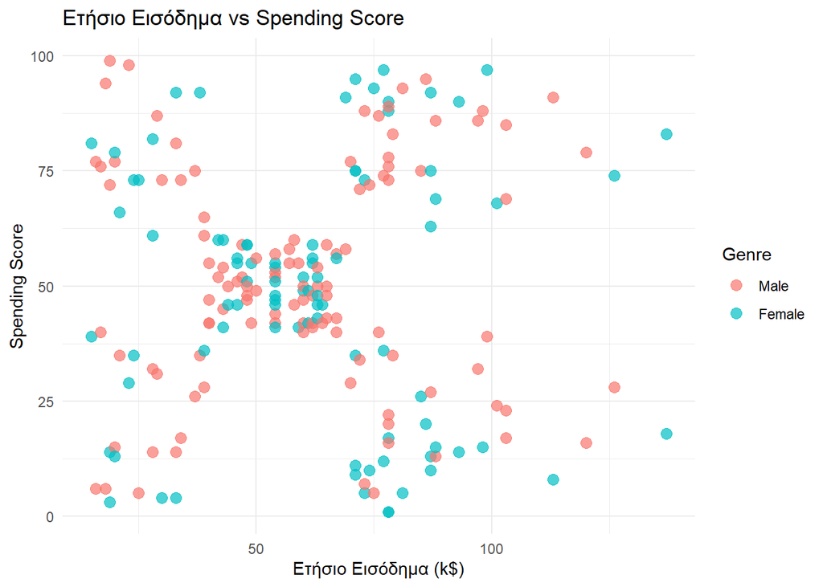

```r
ggplot(customers, aes(x = AnnualIncome, y = SpendingScore, color = Genre)) +
  geom_point(size = 3, alpha = 0.7) +
  labs(title = "Ετήσιο Εισόδημα vs Spending Score",
       x = "Ετήσιο Εισόδημα (k$)",
       y = "Spending Score") +
  theme_minimal()
```

**Σχόλιο**  
Το παραπάνω διάγραμμα δείχνει πώς κατανέμονται οι πελάτες με βάση το ετήσιο εισόδημα και το spending score τους, διαχωρίζοντας τα φύλα. Παρατηρείται ότι δεν υπάρχει ξεκάθαρη γραμμική συσχέτιση, αλλά διακρίνονται ομάδες πελατών με χαμηλό ή υψηλό spending score ανεξάρτητα από το εισόδημα.

## Συσταδοποίηση

### Προετοιμασία των δεδομένων

Προκειμένου να εφαρμόσουμε clustering στο dataset μας, πρέπει να **κανονικοποιήσουμε** τα δεδομένα ώστε να έχουν μέσο όρο 0 και τυπική απόκλιση 1. Με τον τρόπο αυτό, και έχοντας αφαιρέσει την κατηγορική μεταβλητή *Genre* και το μοναδικό αναγνωριστικό *CustomerID*, όλες οι αριθμητικές μεταβλητές παίρνουν την ίδια κλίμακα και αυτές με μεγάλο εύρος δεν μπορούν πλέον να επηρεάσουν υπερβολικά τα αποτελέσματα.

```r
customers_scaled <- scale(customers_numeric)
```

### Ιεραρχική Συσταδοποίηση

```r
distances <- dist(customers_scaled, method = "euclidean")
clusterCustomers <- hclust(distances, method = "ward.D2")
```

**Σχόλια**  
Υπολογίζουμε τις αποστάσεις μεταξύ όλων των παρατηρήσεων στο dataset, αξιοποιώντας την ευκλείδεια απόσταση. Η μέθοδος ward χρησιμοποιείται για να υπολογίσουμε απόσταση μεταξύ των κέντρων των συστάδων.

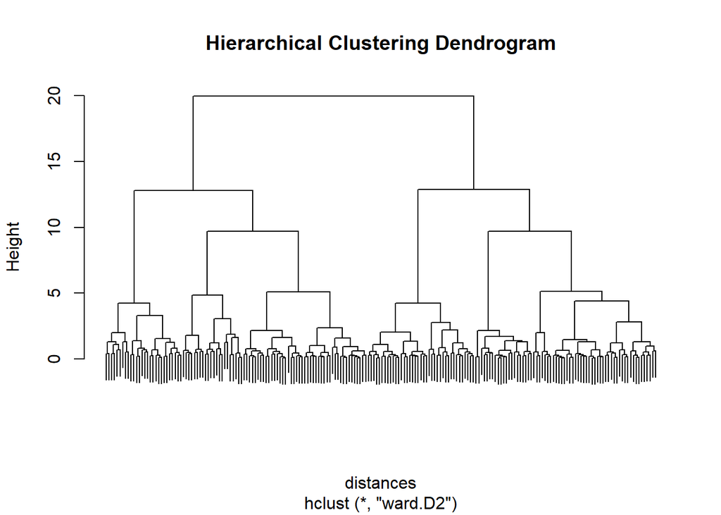

```r
plot(clusterCustomers, labels = FALSE, main = "Hierarchical Clustering Dendrogram")
```

**Σχόλιο**  
Το δενδροδιάγραμμα δείχνει τη διαδικασία συγχώνευσης των datapoints σε ομάδες. Κάθε κατακόρυφη γραμμή αντιστοιχεί στην απόσταση συγχώνευσης δύο clusters και όσο μεγαλύτερο είναι το ύψος, τόσο μεγαλύτερη η διαφορά μεταξύ των ομάδων που συγχωνεύονται. Θα πρέπει να κόψουμε το δέντρο σε ένα σημείο όπου οι συνδέσεις μεταξύ ομάδων είναι μεγάλες, ώστε να βρούμε διακριτά clusters.

Δοκιμάζοντας διάφορες τιμές του k, καταλήγουμε στο συμπέρασμα ότι η βέλτιστη τιμή είναι 5, καθώς για k > 5 πιθανόν να έχουμε overclustering, ενώ για k < 5 έχουμε άνιση κατανομή των datapoints.

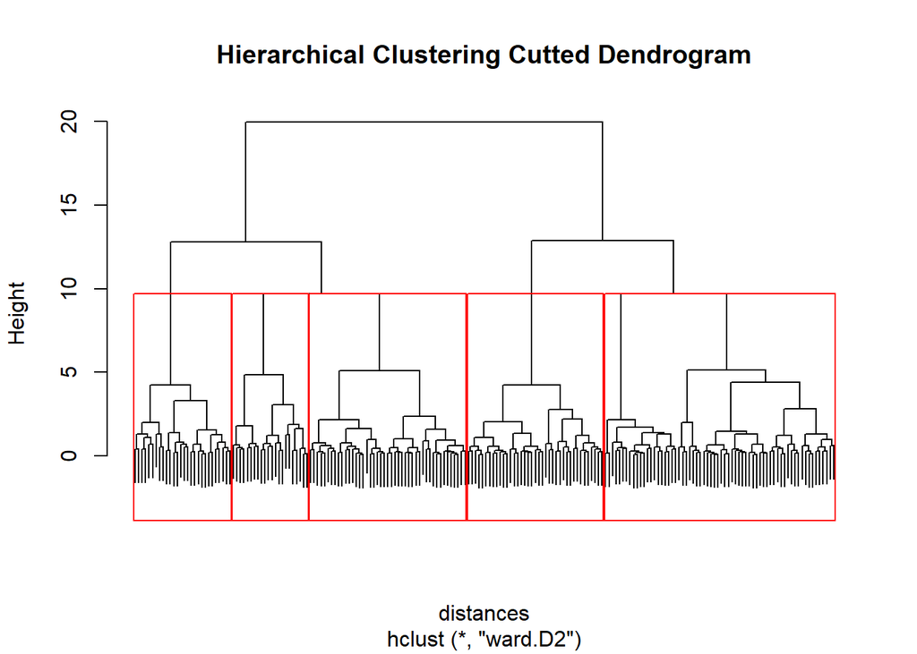

```r
clusterGroups = cutree(clusterCustomers, k=5)
plot(clusterCustomers, labels = FALSE, main = "Hierarchical Clustering Cutted Dendrogram")
rect.hclust(clusterCustomers, k = 5, border = "red")
```

**Σχόλιο**  
Στο κόκκινο πλαίσιο διακρίνεται ο διαχώρισμος των 5 clusters.

Προσθέτουμε τα cluster που δημιουργήσαμε στο αρχικό dataset, σαν κατηγορική μεταβλητή και υπολογίζουμε τον μέσο όρο κάθε μεταβλητής ανά cluster.

```r
customers$HC_Cluster <- factor(clusterGroups)
agg_means <- aggregate(customers_numeric, by = list(Cluster = customers$HC_Cluster), mean)
```

Μέσος όρος μεταβλητών ανά cluster:

| Cluster | Age | Annual Income | Spending Score |
| --- | --- | --- | --- |
| 1 | 44.31818 | 25.77273 | 20.27273 |
| 2 | 26.56061 | 47.36364 | 56.78788 |
| 3 | 56.40000 | 55.28889 | 48.35556 |
| 4 | 32.69231 | 86.53846 | 82.12821 |
| 5 | 43.89286 | 91.28571 | 16.67857 |

**Σχόλια**

### Διαγραμματική Απεικόνιση Clusters

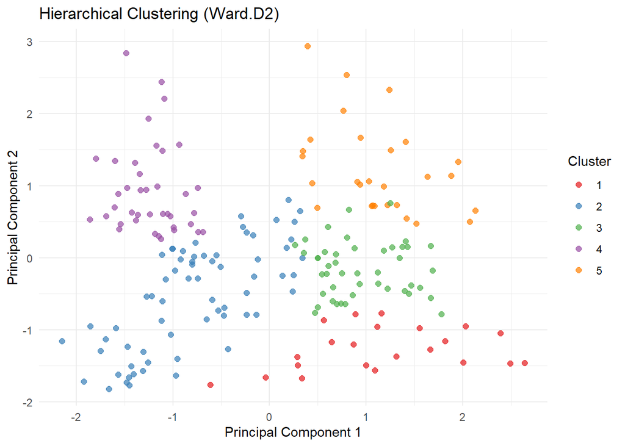

**Σχόλια**  
Το παραπάνω διάγραμμα μας δίνει την κατανομή των datapoints στα 5 διαφορετικά clusters που δημιουργήθηκαν. Παρατηρούμε πως τα περισσότερα clusters διαχωρίζονται αρκετά καθαρά, ειδικά τα Clusters 1 (κόκκινο) και 4 (μωβ) που εμφανίζουν σαφείς περιοχές συγκέντρωσης. Τα Clusters 2 (μπλε) και 3 (πράσινο) έχουν μια μικρή επικάλυψη, που δείχνει ότι ορισμένα σημεία έχουν παρόμοια χαρακτηριστικά. Το Cluster 5 (πορτοκαλί) φαίνεται να καταλαμβάνει ξεχωριστό χώρο, υποδεικνύοντας καλά διακριτό προφίλ πελατών. Η απεικόνιση επιβεβαιώνει ότι η ανάλυση με Ward.D2 παρήγαγε σαφώς διαχωρίσιμες ομάδες, υποστηρίζοντας την ορθότητα της επιλογής k = 5.

### Συσταδοποίηση K-means

```r
set.seed(123)
kmeans_model <- kmeans(customers_scaled, centers = 5, nstart = 25)
```

**Σχόλια**  
Η μέθοδος k-means τοποθετεί τυχαία 5 αρχικά κέντρα και επαναλαμβάνει μετακινήσεις σημείων μεταξύ clusters μέχρι να ελαχιστοποιηθεί η ενδοομαδική διακύμανση. Με το nstart = 25 εκτελούμε την αλγοριθμική διαδικασία από 25 διαφορετικά σημεία εκκίνησης ώστε να βρούμε το βέλτιστο αποτέλεσμα.

Προσθέτουμε τα cluster που δημιουργήσαμε στο αρχικό dataset, σαν κατηγορική μεταβλητή και υπολογίζουμε τον μέσο όρο κάθε μεταβλητής ανά cluster.

```r
customers$KM_Cluster <- factor(kmeans_model$cluster)
agg_means_km <- aggregate(customers_numeric, by = list(Cluster = customers$KM_Cluster), mean)
```

Μέσος όρος μεταβλητών ανά cluster:

| Cluster | Age | Annual Income | Spending Score |
| --- | --- | --- | --- |
| 1 | 32.87500 | 86.10000 | 81.52500 |
| 2 | 25.18519 | 41.09259 | 62.24074 |
| 3 | 39.87179 | 86.10256 | 19.35897 |
| 4 | 55.63830 | 54.38298 | 48.85106 |
| 5 | 46.25000 | 26.75000 | 18.35000 |

### Διαγραμματική Απεικόνιση Clusters

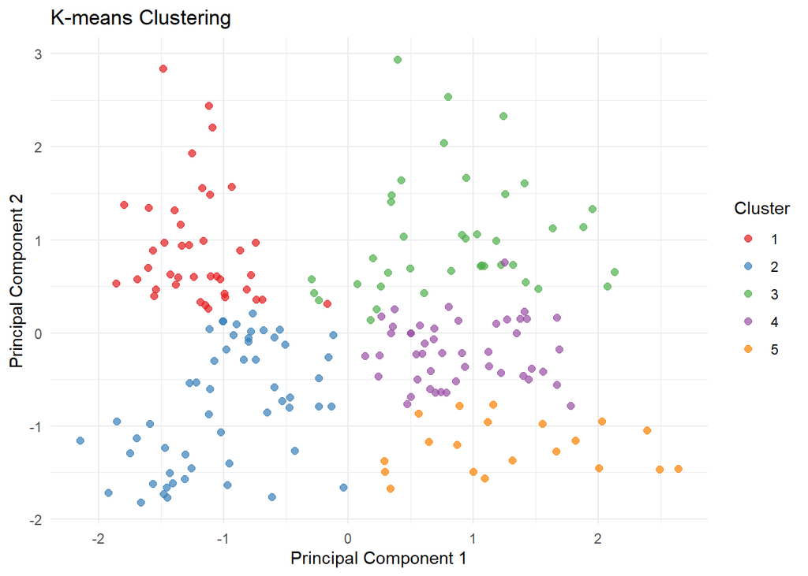

**Σχόλια**  
Το παραπάνω διάγραμμα μας δίνει την κατανομή των datapoints στα 5 διαφορετικά clusters που δημιουργήθηκαν. Παρατηρούμε πως τα περισσότερα clusters διαχωρίζονται αρκετά καθαρά, ειδικά τα Clusters 2 (μπλε) και 5 (πορτοκαλί) που εμφανίζουν σαφείς περιοχές συγκέντρωσης. Τα Clusters 3 (πράσινο), 4 (μωβ) και 1(κόκκινο) έχουν μεταξύ μια μικρή επικάλυψη, που δείχνει ότι ορισμένα σημεία έχουν παρόμοια χαρακτηριστικά. Η απεικόνιση μας παρουσιάζει ότι η ανάλυση με kmeans παρήγαγε καλά διαχωρίσιμες ομάδες, υποστηρίζοντας την ορθότητα της επιλογής k = 5.

### Σύγκριση Μοντέλων

- Και τα δύο μοντέλα κατηγοριοποιούν τα Clusters τους με παρόμοιο τρόπο και αυτό φαίνεται από την διάταξη των datapoints στο χώρο. Αναλυτικότερα κάθε cluster αποτελεί μια ομάδα πελατών με βάση την ηλικία τους, το ετήσιο εισόδημα τους και το spending score. Για το συγκεκριμένο dataset φαίνεται πως η μέθοδος kmeans έχει περισσότερες επικαλύψεις στα datapoints, από την ιεραρχική συσταδοποίηση.
- Γενικότερα, η μέθοδος της ιεραρχικής συσταδοποίησης είναι χρήσιμη για την αρχική διερεύνηση ενός dataset, καθώς με το δενδρόγραμμα παρουσίαζει την φυσική δομή και τον διαχωρισμό των datapoints. Αντιθέτως, η μέθοδος K-means συνήθως προτιμάται στην ομαδοποίηση μεγάλου όγκου δεδομένων και στην λήψη πολύπλοκων επιχειρηματικών αποφάσεων, λόγω της ευκολίας χρήσης και της επαναληψιμότητας που προσφέρει.
- Συνολικά, ο συνδυασμός των δύο τεχνικών θεωρείται καλή πρακτική, δηλαδή πρώτα συστήνεται η ιεραρχική ανάλυση για την κατανόηση του dataset και την εκτίμηση του κατάλληλου k και στη συνέχεια η εφαρμογή του K-means για πιο σταθερή και παραγωγική ομαδοποίηση.